# Employee Performance Analysis (err a pretend version of it)

#### Using Ordered, Hierarchical Logistic Regression

Pretend this is the scenario:

- Employees take a survey with two questions
- Responses are some float number between -2 and 2
- Each employee also has a title and a performance grade equal to either C, B, or A where A is best

The fake data looks like:

```r
head(data)
```

```
## Source: local data frame [6 x 4]
##
##      title performance response.2 response.1
## 1 Engineer           C     -1.385     -1.312
## 2 Engineer           A     -0.501     -1.667
## 3 Engineer           A     -0.485     -1.373
## 4 Engineer           B     -0.462     -0.733
## 5 Engineer           B     -1.846      0.279
## 6 Engineer           B     -1.297     -0.602
```

And the fake data is created so **response.2** is a random number and **response.1** is ACTUALLY related to performance.

**Response.1** is related in a different way for each employee title though, but in all cases the performance goes up as that response goes up (perhaps the question was like “How hard do you work?” – so it should be indicative of performance). It just goes up more quickly for some jobs more than others:

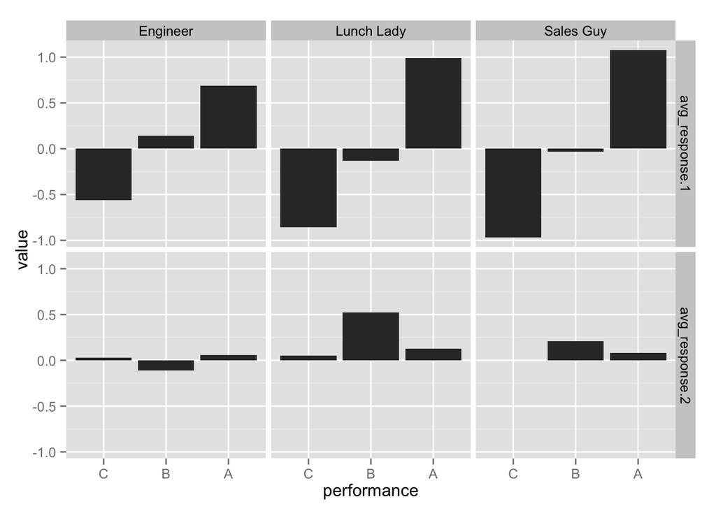

```r
# Average response values by title and performance:
# note that performance goes up as response.1 goes up
library(reshape2)
data %>%
  group_by(title, performance) %>%
  summarise(
    avg_response.1=round(mean(response.1), 2),
    avg_response.2=round(mean(response.2), 2)
  ) %>% melt(id.vars=c('title', 'performance')) %>%
  ggplot(aes(x=performance, y=value)) + geom_bar(stat='identity', position='dodge') +
  facet_grid(variable~title)
```

Again response.2 is just nonsense and response.1 has an actual relationship with performance defined like:

```r
# These are the values the model should be able to recover
engineer.slope <- .9
lunch.lady.slope <- 2.1
sales.guy.slope <- 5.1
```

### Creating a Model

The point then will be to determine how as the response values change, the performance changes as well **PER job title**.

One way to do this with stan is to use an ordered logistic model where the slope per job title varies:

```r
### Create a 'Performance' model based on employee survey responses,
### with a hierarchical separation for each job title

stan.model <- '
  data {
    int<lower=2> N_PERF_VALS;                // # of possible performance measures like "A" or "B", etc.
    int<lower=0> N_OBS;                      // # of employees in question (i.e. number of observations)
    int<lower=1> N_VARS;                     // # of survey responses
    int<lower=1> N_JOBS;                     // # of different titles possible
    int<lower=1,upper=N_PERF_VALS> y[N_OBS]; // Vector of performance evaluations
    int<lower=1> g[N_OBS];                   // "Group" or rather "Job title" for each employee
    row_vector[N_VARS] x[N_OBS];             // Matrix of survey responses for each employee
  }
  parameters {
    vector[N_VARS] beta[N_JOBS];   // Slope estimates by job title
    ordered[N_PERF_VALS-1] cutpoints;
  }
  model {
    // Assign normal priors to coefficients to estimate
    for (i in 1:N_JOBS)
      beta[i]  ~ normal(0,10);

    // Create model where the output is predicted by the per-job-title
    // intercept plus the per-job-title slope times each survey response value
    for (i in 1:N_OBS)
      y[i] ~ ordered_logistic(x[i] * beta[g[i]], cutpoints);
  }
'
```

Now feed the data to Stan and run the model:

```r
# Convert the raw data created into Stan data
d <- list(
  N_PERF_VALS = length(levels(data$performance)), # One for each performance grade (A, B, or C)
  N_OBS = nrow(data),
  N_VARS = 2,  # One for each of the two survey responses
  N_JOBS = 3,  # One for each of the job titles
  y = as.integer(data$performance),         # These are the performance grades
  x = data[,c('response.1', 'response.2')], # These are the survey responses
  g = as.integer(data$title)                # And these are integers corresponding to each job title
)

# Run the sampler
fit <- stan(model_code = stan.model, data = d, warmup = 100, iter = 1000, thin = 5, chains = 1, verbose = FALSE)
```

[output not shown]

Take the sampled parameter estimates out of the stan model and plot the posterior estimates.

Also show the **ACTUAL** value for each parameter used to generate the data in the first place as a red line:

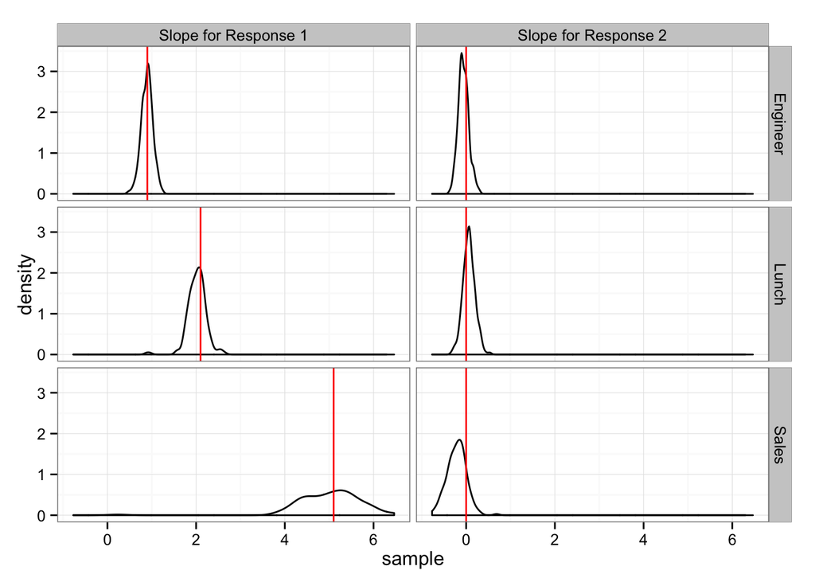

```r
samples <- extract.samples(fit)

vlines <- samples %>% group_by(title, param, response) %>% summarise(actual=actual[1])

ggplot(samples, aes(x=sample)) + geom_density() +
  facet_grid(title~response) +
  geom_vline(aes(xintercept=actual), color='red', data = vlines) + theme_bw()
```